# GEO 200CN Lab 2

Kenneth Larrieu

April 10, 2019

#### Question 1.1

The primary difference between the two maps used in OSU vs. rspatial is that the rspatial map used is much higher resolution. As a result, even when the same yardstick is used, the rspatial map results in a longer coastline length.

#### Question 2.1: Create these matrices from `ind` and `dep` without using `byrow=TRUE`.

```r
# independent variable
ind <- c(87, 95, 72, 37, 44, 24,
         40, 55, 55, 38, 88, 34,
         41, 30, 26, 35, 38, 24,
         14, 56, 37, 34,  8, 18,
         49, 44, 51, 67, 17, 37,
         55, 25, 33, 32, 59, 54)
# dependent variable
dep <- c(72, 75, 85, 29, 58, 30,
         50, 60, 49, 46, 84, 23,
         21, 46, 22, 42, 45, 14,
         19, 36, 48, 23,  8, 29,
         38, 47, 52, 52, 22, 48,
         58, 40, 46, 38, 35, 55)

# create matrices filling by column (default), then transpose
mi <- t(matrix(ind, ncol=6, nrow=6))
md <- t(matrix(dep, ncol=6, nrow=6))
```

#### Question 2.2: Instead of the `mean` function What other functions could, in principle, reasonably be used in an aggregation of raster cells?

Other functions that could be reasonably used to aggregate raster data include `sum`, `range`, `min`, `max`, `sd`, etc.

#### Question 2.3: There are other ways to do the above (converting two RasterLayer objects to a `data.frame`). Show how to obtain the same result (`d1`) using `as.vector` and `cbind`.

```r
# load package
library(raster)
# turn matrices into RasterLayer objects
ri = raster(mi)
rd = raster(md)

# aggregate individually
ai1 = aggregate(ri, c(2, 1), fun=mean)
ad1 = aggregate(rd, c(2, 1), fun=mean)

# then combine into data.frame
d1 = data.frame(ind=as.vector(ai1), dep=as.vector(ad1))
d1
```

```
##     ind  dep
## 1  91.0 73.5
## 2  54.5 57.0
## 3  34.0 44.0
## 4  47.5 55.0
## 5  46.5 47.5
## 6  61.0 53.5
## 7  35.5 33.5
## 8  30.5 32.0
## 9  31.0 29.5
## 10 35.0 27.5
## 11 35.5 35.5
## 12 13.0 18.5
## 13 46.5 42.5
## 14 59.0 52.0
## 15 27.0 35.0
## 16 40.0 49.0
## 17 32.5 42.0
## 18 56.5 45.0
```

#### Question 2.4: Show R code to make a cluster dendogram summarizing the distances between these six sites, and plot it.

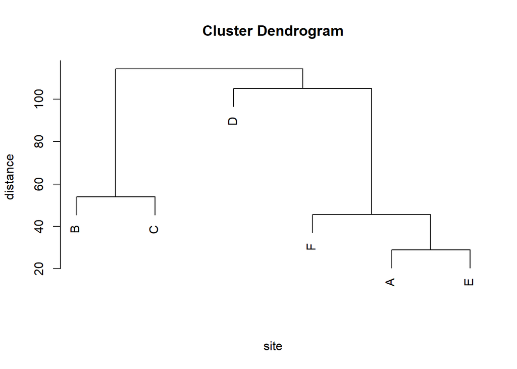

```r
A = c(40, 43)
B = c(1, 101)
C = c(54, 111)
D = c(104, 65)
E = c(60, 22)
F = c(20, 2)
# create data.frame of point coordinates
pts = rbind(A,B,C,D,E,F)
# create distance matrix
dis = dist(pts)
D = as.matrix(dis)
D = round(D)
# create dendrogram object
hc = hclust(dis)
plot(hc, xlab='site', ylab='distance', sub='')
```

#### Question 2.5: Show how you can do ‘column-normalization’ (Just an exercise, in spatial data analysis this is not a typical thing to do).

```r
# create weights matrix
W = 1 / D
W[!is.finite(W)] = NA
W = round(W, 4)
# get column totals
ctot = colSums(W, na.rm=TRUE)
# divide entries in each column by corresponding column total
W = W / rep(ctot, each=nrow(W))
# check that columns are now normalized
colSums(W, na.rm=TRUE)
```

```
## A B C D E F
## 1 1 1 1 1 1
```

#### Question 2.6: The `SpatialPolygonDataFrame` class is defined in package sp. But we never used library(‘sp’) . So how is it possible that we have one of such objects?

R automatically installs dependencies that are missing when a package is imported from the library. While `sp` was not imported explicitly, it was imported as a dependency of `dismo`.

#### ISLR 2.4.9:

*a.* Which of the predictors are quantitative, and which are qualitative?

```r
head(Auto)
```

```
##   mpg cylinders displacement horsepower weight acceleration year origin
## 1  18         8          307        130   3504         12.0   70      1
## 2  15         8          350        165   3693         11.5   70      1
## 3  18         8          318        150   3436         11.0   70      1
## 4  16         8          304        150   3433         12.0   70      1
## 5  17         8          302        140   3449         10.5   70      1
## 6  15         8          429        198   4341         10.0   70      1
##                        name
## 1 chevrolet chevelle malibu
## 2         buick skylark 320
## 3        plymouth satellite
## 4             amc rebel sst
## 5               ford torino
## 6          ford galaxie 500
```

From looking at the data, we see all values are quantitative except for “origin” and “name”. While “origin” is numeric, it represents a physical location and not an actual quantitative measure.

*b.* What is the range of each quantitative predictor?

```r
# only first 7 columns (quantitative)
autoq = Auto[1:7]
# apply rannge function column-wise
apply(autoq, 2, range)
```

```
##       mpg cylinders displacement horsepower weight acceleration year
## [1,]  9.0         3           68         46   1613          8.0   70
## [2,] 46.6         8          455        230   5140         24.8   82
```

*c.* What is the mean and standard deviation of each quantitative predictor?

mean:

```r
apply(autoq, 2, mean)
```

```
##          mpg    cylinders displacement   horsepower       weight
##    23.445918     5.471939   194.411990   104.469388  2977.584184
## acceleration         year
##    15.541327    75.979592
```

standard deviation:

```r
apply(autoq, 2, sd)
```

```
##          mpg    cylinders displacement   horsepower       weight
##     7.805007     1.705783   104.644004    38.491160   849.402560
## acceleration         year
##     2.758864     3.683737
```

*d.* Now remove the 10th through 85th observations. What is the range, mean, and standard deviation of each predictor in the subset of the data that remains?

```r
autorm = autoq[, -10:-85]
```

range:

```r
apply(autorm, 2, range)
```

```
##       mpg cylinders displacement horsepower weight acceleration year
## [1,]  9.0         3           68         46   1613          8.0   70
## [2,] 46.6         8          455        230   5140         24.8   82
```

mean:

```r
apply(autorm, 2, mean)
```

```
##          mpg    cylinders displacement   horsepower       weight
##    23.445918     5.471939   194.411990   104.469388  2977.584184
## acceleration         year
##    15.541327    75.979592
```

standard deviation:

```r
apply(autorm, 2, sd)
```

```
##          mpg    cylinders displacement   horsepower       weight
##     7.805007     1.705783   104.644004    38.491160   849.402560
## acceleration         year
##     2.758864     3.683737
```

*e.* Using the full data set, investigate the predictors graphically, using scatterplots or other tools of your choice. Create some plots highlighting the relationships among the predictors. Comment on your findings.

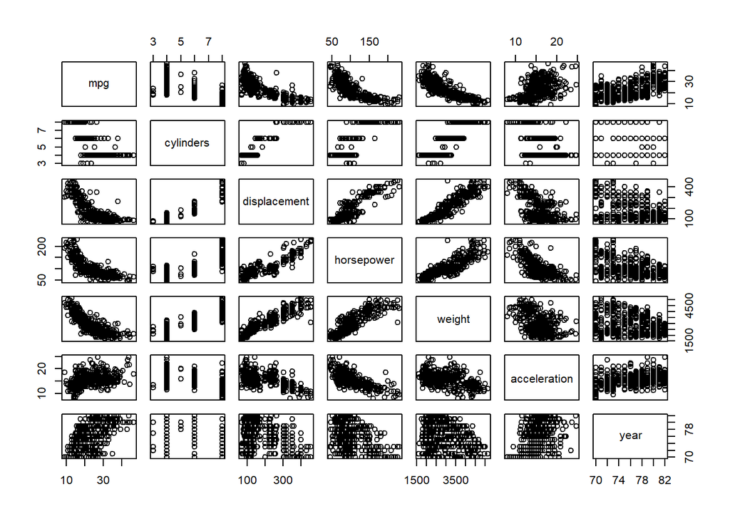

```r
# plot all pairs of variables in autorm
pairs(autorm)
```

From the above plot, we see that some pairs of variables appear to have a strong linear relationship (e.g. horsepower and weight) while other pairs appear to be weakly related or unrelated (e.g. weight and year).

*f.* Suppose that we wish to predict gas mileage (mpg) on the basis of the other variables. Do your plots suggest that any of the other variables might be useful in predicting mpg? Justify your answer.

Going off a visual interpretation of the plots, the strongest predictors of mpg appear to be displacement, horsepower, and weight. All three of these variables appear to negatively effect mpg, which intuitively makes sense as well.

#### ISLR 3.7.8:

*a.* Use the `lm()` function to perform a simple linear regression with `mpg` as the response and `horsepower` as the predictor. Use the `summary()` function to print the results. Comment on the output.

```r
mpg = Auto$mpg
horsepower = Auto$horsepower
m = lm(mpg ~ horsepower)
summary(m)
```

```
##
## Call:
## lm(formula = mpg ~ horsepower)
##
## Residuals:
##      Min       1Q   Median       3Q      Max
## -13.5710  -3.2592  -0.3435   2.7630  16.9240
##
## Coefficients:
##              Estimate Std. Error t value Pr(>|t|)
## (Intercept) 39.935861   0.717499   55.66   <2e-16 ***
## horsepower  -0.157845   0.006446  -24.49   <2e-16 ***
## ---
## Signif. codes:  0 '***' 0.001 '**' 0.01 '*' 0.05 '.' 0.1 ' ' 1
##
## Residual standard error: 4.906 on 390 degrees of freedom
## Multiple R-squared:  0.6059, Adjusted R-squared:  0.6049
## F-statistic: 599.7 on 1 and 390 DF,  p-value: < 2.2e-16
```

Due to the $p \ll 0.05$, we can reject the null hypothesis and conclude there is a negative relationship between mpg and horsepower. Increasing the horsepower by $1$ approximately decreases the mpg by $0.15$. Thus, due to the range of variability of horsepower, it has a strong influence on mpg, e.g. for a difference of only $10$ horsepower implies a notable difference of $1.5$ miles per gallon. For a horsepower of $98$, the predicted mpg is (along with corresponding confidence and prediction intervals at the $95%$ level):

```r
# print predicted value with confidence intervals
predict(m, data.frame(horsepower=c(98)), interval='confidence')
```

```
##        fit      lwr      upr
## 1 24.46708 23.97308 24.96108
```

```r
# print predicted value with prediction intervals
predict(m, data.frame(horsepower=c(98)), interval='prediction')
```

```
##        fit     lwr      upr
## 1 24.46708 14.8094 34.12476
```

*b.* Plot the response and the predictor. Use the `abline()` function to display the least squares regression line.

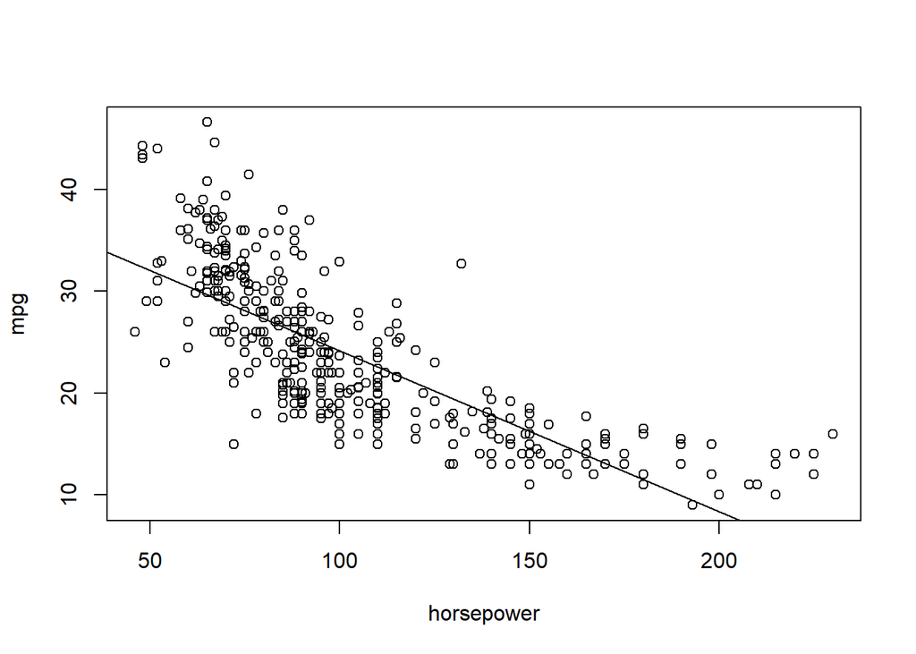

```r
# data scatter plot
plot(horsepower, mpg)
# plot line of best fit using model coefficients
abline(coef(m))
```

*c.* Use the `plot()` function to produce diagnostic plots of the least squares regression fit. Comment on any problems you see with the fit.

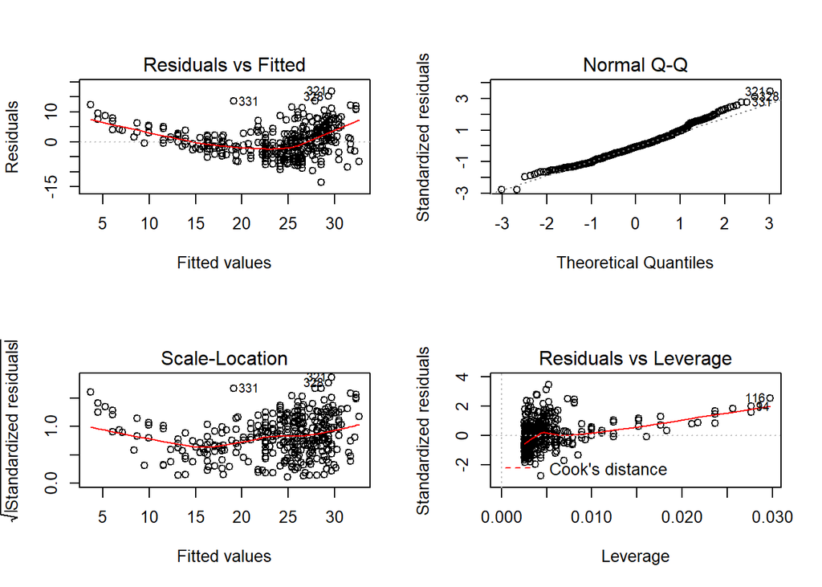

```r
par(mfrow=c(2,2))
plot(m)
```